# Homework 2: Sampling and Iteration in the Tidyverse

Wendi White

9/20/2020

1. Some Data with Flippers

1a. Load the library palmerpenguins after installing it.

```r
#removed install R code b/c couldn't knit file but did put install.packages("palmerpenguins")
library("palmerpenguins") #load in the library
```

1b. Show the head of the dataset penguins

```r
head(penguins) #head() to look at first 6 rows of data set
```

```
## # A tibble: 6 x 8
##   species island bill_length_mm bill_depth_mm flipper_length_… body_mass_g sex
##   <fct>   <fct>           <dbl>         <dbl>            <int>       <int> <fct>
## 1 Adelie  Torge…           39.1          18.7              181        3750 male
## 2 Adelie  Torge…           39.5          17.4              186        3800 fema…
## 3 Adelie  Torge…           40.3          18                195        3250 fema…
## 4 Adelie  Torge…           NA            NA                 NA          NA <NA>
## 5 Adelie  Torge…           36.7          19.3              193        3450 fema…
## 6 Adelie  Torge…           39.3          20.6              190        3650 male
## # … with 1 more variable: year <int>
```

1c. What do you learn by using str() and summary() on penguins()

Str tells us that we have 8 categories in our data set and I can get a glimpse at the fact we have NA’s. Summary we learn there how many NA’s in our data set so we’ll need to use code na.rm= TRUE for future codes.

```r
str(penguins) #str data
```

```
## tibble [344 × 8] (S3: tbl_df/tbl/data.frame)
##  $ species          : Factor w/ 3 levels "Adelie","Chinstrap",..: 1 1 1 1 1 1 1 1 1 1 ...
##  $ island           : Factor w/ 3 levels "Biscoe","Dream",..: 3 3 3 3 3 3 3 3 3 3 ...
##  $ bill_length_mm   : num [1:344] 39.1 39.5 40.3 NA 36.7 39.3 38.9 39.2 34.1 42 ...
##  $ bill_depth_mm    : num [1:344] 18.7 17.4 18 NA 19.3 20.6 17.8 19.6 18.1 20.2 ...
##  $ flipper_length_mm: int [1:344] 181 186 195 NA 193 190 181 195 193 190 ...
##  $ body_mass_g      : int [1:344] 3750 3800 3250 NA 3450 3650 3625 4675 3475 4250 ...
##  $ sex              : Factor w/ 2 levels "female","male": 2 1 1 NA 1 2 1 2 NA NA ...
##  $ year             : int [1:344] 2007 2007 2007 2007 2007 2007 2007 2007 2007 2007 ...
```

```r
summary(penguins) #summarize to get more info on data like NA's mean, med, etc of each column
```

```
##       species          island    bill_length_mm  bill_depth_mm
##  Adelie   :152   Biscoe   :168   Min.   :32.10   Min.   :13.10
##  Chinstrap: 68   Dream    :124   1st Qu.:39.23   1st Qu.:15.60
##  Gentoo   :124   Torgersen: 52   Median :44.45   Median :17.30
##                                  Mean   :43.92   Mean   :17.15
##                                  3rd Qu.:48.50   3rd Qu.:18.70
##                                  Max.   :59.60   Max.   :21.50
##                                  NA's   :2       NA's   :2
##  flipper_length_mm  body_mass_g       sex           year
##  Min.   :172.0     Min.   :2700   female:165   Min.   :2007
##  1st Qu.:190.0     1st Qu.:3550   male  :168   1st Qu.:2007
##  Median :197.0     Median :4050   NA's  : 11   Median :2008
##  Mean   :200.9     Mean   :4202                Mean   :2008
##  3rd Qu.:213.0     3rd Qu.:4750                3rd Qu.:2009
##  Max.   :231.0     Max.   :6300                Max.   :2009
##  NA's   :2         NA's   :2
```

1d. What are the quantiles of bill depth across the whole data set? What do those quantiles mean?

The quantiles tell us what values fall below certain % of our data. Most common is knowing the median (17.3) of our data to determine the value where 50% of numbers will fall above and below. 0% of number fall below 13.1, 25% of numbers fall below 15.6, 50% of numbers fall below (and above) 17.3, 75% of numbers fall below 18.7, and 100% of numbers fall below 21.5. 13.1 is min, 17.3 is median, and 21.5 is max.

```r
quantile(penguins$bill_depth_mm, na.rm = TRUE) #use quantile() function to find the quantiles of bill depth. excludes NAs
```

```
##   0%  25%  50%  75% 100%
## 13.1 15.6 17.3 18.7 21.5
```

2. What’s here? Let’s use dplyr!

2a. If I have a vector, c(1,4,7,NA,9), what is its mean? Note, the NA is going to cause a problem. Look at ?mean to learn how to solve it.

Mean = 5.25

```r
library(dplyr) #attach dplyr
vec_two <- c(1,4,7,NA,9) #name/create the vector
mean(vec_two, na.rm = TRUE) #find mean of vector but note NAs and eliminate them
```

```
## [1] 5.25
```

2b. What is the mean, sd, and median of body mass across the data set? Note, these NAs are going to cause some problems, so you might need to look at the documentation for the relevant functions.

mean= 4201.754 sd= 801.9545 median= 4050

```r
mean(penguins$body_mass_g, na.rm = TRUE) #find mean, ignore NAs
```

```
## [1] 4201.754
```

```r
sd(penguins$body_mass_g, na.rm=TRUE) #find sd, ignore NAs
```

```
## [1] 801.9545
```

```r
median(penguins$body_mass_g, na.rm = TRUE) #find median, ignore NAs
```

```
## [1] 4050
```

2c. Repeat 2b, but, show us how these quantities differ by species

```r
library(dplyr)
peng_msm <- penguins%>% #new name and using data penguins
   group_by(species)%>% #group by species
  summarize(avg_bm = mean(body_mass_g, na.rm = TRUE), #summarize to find sd, mean and median of body mass
            sd_bm = sd(body_mass_g, na.rm=TRUE),
            med_bm = median(body_mass_g, na.rm = TRUE))
peng_msm
```

```
## # A tibble: 3 x 4
##   species   avg_bm sd_bm med_bm
##   <fct>      <dbl> <dbl>  <dbl>
## 1 Adelie     3701.  459.   3700
## 2 Chinstrap  3733.  384.   3700
## 3 Gentoo     5076.  504.   5000
```

2d. Repeat 2c, but just for Biscoe island. What is different in the results?

There are no Chinstraps on the island and Gentoo’s are only found on Biscoe island b/c none of the values change. Adelie values change a bit b/c they must be found on other islands too.

```r
peng_msm_biscoe <- penguins%>% #new name/ data set pulling from
  filter(island=="Biscoe")%>% #filter for just biscoe
  group_by(species)%>% #group by species
  summarize(avg_bm_bis = mean(body_mass_g, na.rm = TRUE), #summarize to get avg, sd and median of body mass
            sd_bm_bis = sd(body_mass_g, na.rm=TRUE),
            med_bm_bis = median(body_mass_g, na.rm = TRUE))
peng_msm_biscoe
```

```
## # A tibble: 2 x 4
##   species avg_bm_bis sd_bm_bis med_bm_bis
##   <fct>        <dbl>     <dbl>      <dbl>
## 1 Adelie       3710.      488.       3750
## 2 Gentoo       5076.      504.       5000
```

2E Make a species-island column in penguins using paste(). This is an awesome function that takes multiple strings, and slams them together using the argument sep = to define how the string should be combined. Try out paste(“Hello”, “Goodbye”, sep = “!”) to see how it works. Have the two be separated by _.

```r
paste("Hello", "Goodbye", sep = "!") #paste attempt, use "" b/c words
```

```
## [1] "Hello!Goodbye"
```

```r
?paste #look into paste function
library(dplyr) #load dplyr
species_island_peng <- penguins%>% #new name for data, pull data from penguins data set
  mutate("species_island" = paste(species, island, sep = "_")) #add in column using mutate. call it species_island. species island combines columns species and island
species_island_peng #view data
```

```
## # A tibble: 344 x 9
##    species island bill_length_mm bill_depth_mm flipper_length_… body_mass_g
##    <fct>   <fct>           <dbl>         <dbl>            <int>       <int>
##  1 Adelie  Torge…           39.1          18.7              181        3750
##  2 Adelie  Torge…           39.5          17.4              186        3800
##  3 Adelie  Torge…           40.3          18                195        3250
##  4 Adelie  Torge…           NA            NA                 NA          NA
##  5 Adelie  Torge…           36.7          19.3              193        3450
##  6 Adelie  Torge…           39.3          20.6              190        3650
##  7 Adelie  Torge…           38.9          17.8              181        3625
##  8 Adelie  Torge…           39.2          19.6              195        4675
##  9 Adelie  Torge…           34.1          18.1              193        3475
## 10 Adelie  Torge…           42            20.2              190        4250
## # … with 334 more rows, and 3 more variables: sex <fct>, year <int>,
## #   species_island <chr>
```

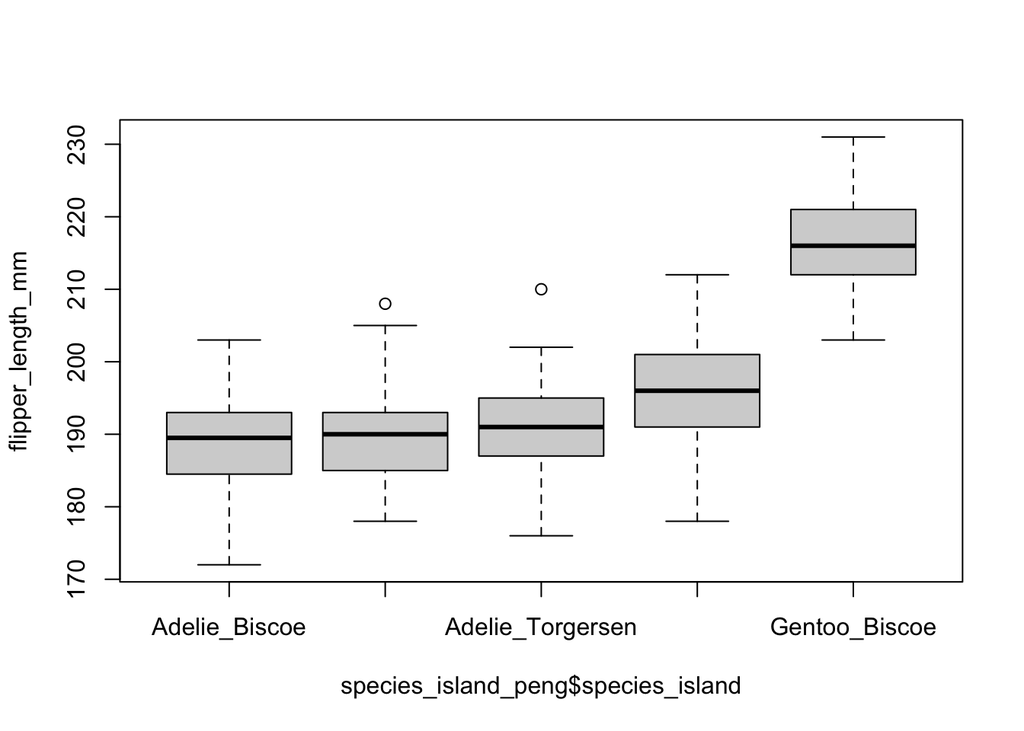

```r
boxplot(flipper_length_mm ~ species_island_peng$species_island, data = species_island_peng) #box plot of flipper length (y) by species_island (x) using function created above species_island
```

```r
species_island_peng_ec <- penguins%>% #new name for data, pull data from penguins data set
  mutate("species_islands" =  (paste(species, island, sep = '\n'))) #mutate to add column and call it species_islands. Use \n to separate though when you add in function cat(paste( , sep='\n'))

species_island_peng_ec_cat <- penguins%>% #new name for data, pull data from penguins data set
  mutate("species_islands" =  cat(paste(species, island, sep = '\n')))
```

[output not shown]

[output cut: 290 more lines]

[output not shown]

3b. Show the relationship between average flipper length and average body mass by species and island. What do you see?

You can see there is a big gap in data where the 5100g looks like an outlier

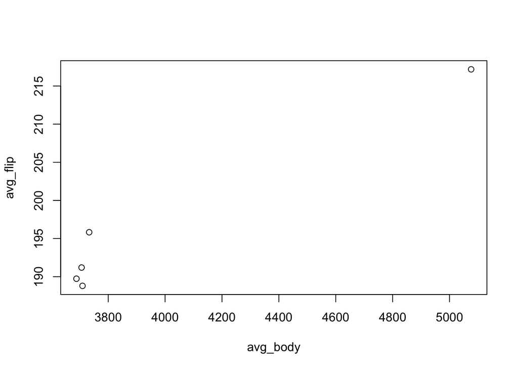

```r
peng_afl_abm <- species_island_peng%>% #new name for plot, using data that has new species_island column
  group_by(species_island)%>% #group by this column
  summarize(avg_flip=mean(flipper_length_mm, na.rm = TRUE), avg_body= mean(body_mass_g, na.rm = TRUE))%>% #looking at avg flipper length vs avg body mass
 plot(avg_flip~avg_body, data= .) # plot the flip vs body
```

```r
peng_afl_abm #view graph
```

3c. Interesting. What if you had made the same plot with the whole dataset? What do you see? Is there anything that could clarify the result any more? Think about it - lots of possible right answers here.

By plotting all of the data on graph one we see that our average of everything is way different because of the big bird that’s pulling our average up.

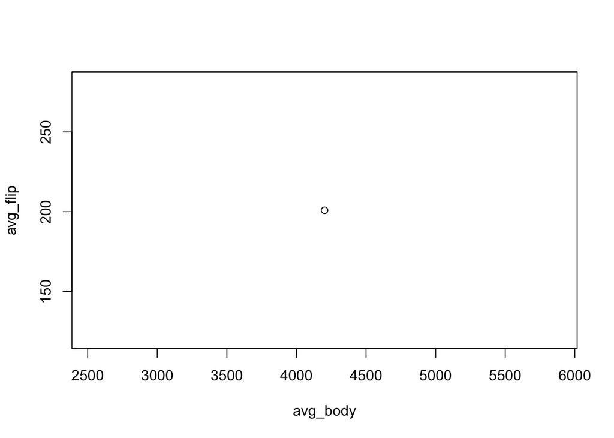

```r
peng_afl_ <- species_island_peng%>% #new name for plot, using data that has new species_island column
  summarize(avg_flip=mean(flipper_length_mm, na.rm = TRUE), avg_body= mean(body_mass_g, na.rm = TRUE))%>% #looking at avg flipper length vs avg body mass
 plot(avg_flip~avg_body, data= .) # plot the flip vs body
```

```r
peng_afl_ #view graph
```

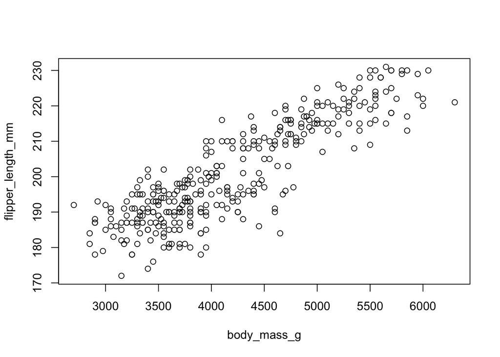

```r
plot(flipper_length_mm~body_mass_g, data = species_island_peng) # new plot without averages and no species by island just to further look at the data
```

4. Let’s get ready to simulate

4a. Grab the values for bill_length_mm for Gentoo penguins in Biscoe Island and put it into an object. Note, the dplyr function pull() is kinda cool, as if you apply it to a data frame, it will pull out a vector from a column of interest. Try 21, 21, 22.8, 21.4, 18.7, 18.1, 14.3, 24.4, 22.8, 19.2, 17.8, 16.4, 17.3, 15.2, 10.4, 10.4, 14.7, 32.4, 30.4, 33.9, 21.5, 15.5, 15.2, 13.3, 19.2, 27.3, 26, 30.4, 15.8, 19.7, 15, 21.4. Kinda cool. Might help you here.

```r
library(dplyr)
bill <- penguins%>% #new name for object
  filter(species=="Gentoo", island=="Biscoe")%>% #filter so you get gentoos on biscoe island
  select(bill_length_mm)%>% #selet for just bill length
  pull() #pull out this data
bill #note NA
```

```
##   [1] 46.1 50.0 48.7 50.0 47.6 46.5 45.4 46.7 43.3 46.8 40.9 49.0 45.5 48.4 45.8
##  [16] 49.3 42.0 49.2 46.2 48.7 50.2 45.1 46.5 46.3 42.9 46.1 44.5 47.8 48.2 50.0
##  [31] 47.3 42.8 45.1 59.6 49.1 48.4 42.6 44.4 44.0 48.7 42.7 49.6 45.3 49.6 50.5
##  [46] 43.6 45.5 50.5 44.9 45.2 46.6 48.5 45.1 50.1 46.5 45.0 43.8 45.5 43.2 50.4
##  [61] 45.3 46.2 45.7 54.3 45.8 49.8 46.2 49.5 43.5 50.7 47.7 46.4 48.2 46.5 46.4
##  [76] 48.6 47.5 51.1 45.2 45.2 49.1 52.5 47.4 50.0 44.9 50.8 43.4 51.3 47.5 52.1
##  [91] 47.5 52.2 45.5 49.5 44.5 50.8 49.4 46.9 48.4 51.1 48.5 55.9 47.2 49.1 47.3
## [106] 46.8 41.7 53.4 43.3 48.1 50.5 49.8 43.5 51.5 46.2 55.1 44.5 48.8 47.2   NA
## [121] 46.8 50.4 45.2 49.9
```

4b. Use replicate() to calculate the standard error of the mean 10 times. Use a formula! Don’t forget that NA values shouldn’t be included!

se= 0.276759

```r
str(bill, na.rm=TRUE) #str to check for NA's and find length of data set(124)
```

```
##  num [1:124] 46.1 50 48.7 50 47.6 46.5 45.4 46.7 43.3 46.8 ...
```

```r
replicate(10, (sd(bill, na.rm = TRUE) / sqrt(124)))  #replicate to calc se 10 times ( n=10). Used equation sd / sqrt (length of data set)
```

```
##  [1] 0.276759 0.276759 0.276759 0.276759 0.276759 0.276759 0.276759 0.276759
##  [9] 0.276759 0.276759
```

4c. Use map_df() to create a data frame with the mean and sd of different sample sizes using the first 5 through 100 values (so, n = 5:100 - smallest sample size will have the values 1-5). Make sure the sample size is included in the final data frame.

```r
library(purrr) #load purr for map_df

?map_df
df_new <- map_df(5:100, ~data.frame(m= mean(bill[1:.x]), #map_df to create data frame. for values 5-100. We are asking it to return two things the mean (m) and sd (s). using indicies from our vector 1- the chosen number (.x)
                           s= sd(bill[1:.x])),
         .id = "x") #to retain the value (1-96 column)
df_new
```

```
##     x        m        s
## 1   1 48.48000 1.666433
## 2   2 48.15000 1.695582
## 3   3 47.75714 1.864454
## 4   4 47.62500 1.766150
## 5   5 47.14444 2.192665
## 6   6 47.11000 2.070132
## 7   7 46.54545 2.713435
## 8   8 46.75000 2.682434
## 9   9 46.65385 2.591530
## 10 10 46.77857 2.533219
## 11 11 46.71333 2.454112
## 12 12 46.87500 2.457506
## 13 13 46.58824 2.657038
## 14 14 46.73333 2.650194
```

[output cut: 82 more lines]

4d. Plot the relationship between sample size and SD and sample size versus SE of the mean. What difference do you see and why? Note, you’ll need to create a column for SE here!

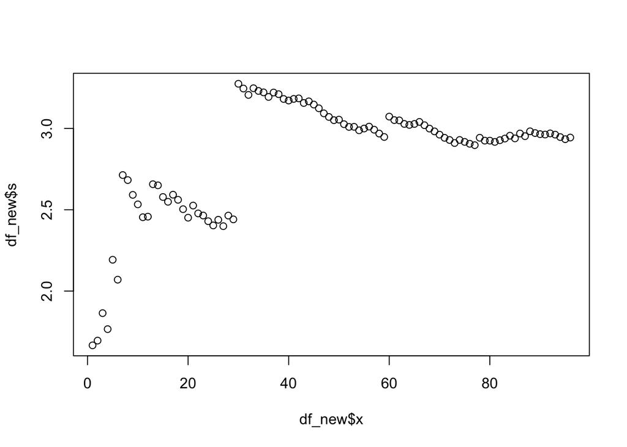

```r
plot(df_new$x, df_new$s) #plot of sample size vs SD
```

```r
df_new_se <- map_df(5:100, ~data.frame(m= mean(bill[1:.x]), #create SE by copying data from above and adding se in with same explanation other than I added in the equation of SE
                           s= sd(bill[1:.x]),
                           se= (sd(bill[1:.x]))/sqrt(96)),
         .id = "x")
df_new_se
```

```
##     x        m        s        se
## 1   1 48.48000 1.666433 0.1700796
## 2   2 48.15000 1.695582 0.1730547
## 3   3 47.75714 1.864454 0.1902901
## 4   4 47.62500 1.766150 0.1802569
## 5   5 47.14444 2.192665 0.2237879
## 6   6 47.11000 2.070132 0.2112819
## 7   7 46.54545 2.713435 0.2769388
## 8   8 46.75000 2.682434 0.2737748
## 9   9 46.65385 2.591530 0.2644969
## 10 10 46.77857 2.533219 0.2585456
## 11 11 46.71333 2.454112 0.2504718
## 12 12 46.87500 2.457506 0.2508181
## 13 13 46.58824 2.657038 0.2711828
## 14 14 46.73333 2.650194 0.2704843
```

[output cut: 82 more lines]

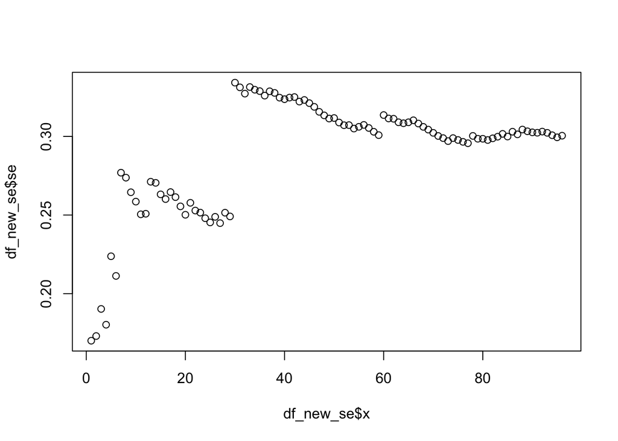

```r
plot(df_new_se$x, df_new_se$se) #plotting the sample size vs SE
```

+2 EC for using par() to make a two-panel plot. Don’t forget to reset back to a single plot per panel after making a two-panel plot. Otherwise things get weird.

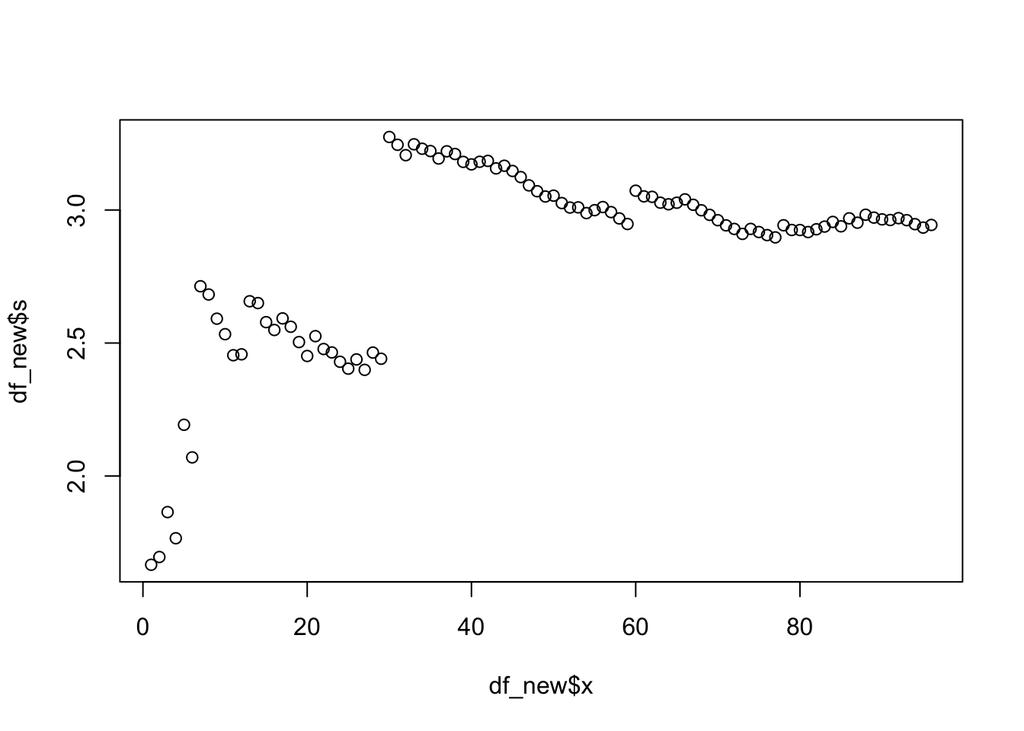

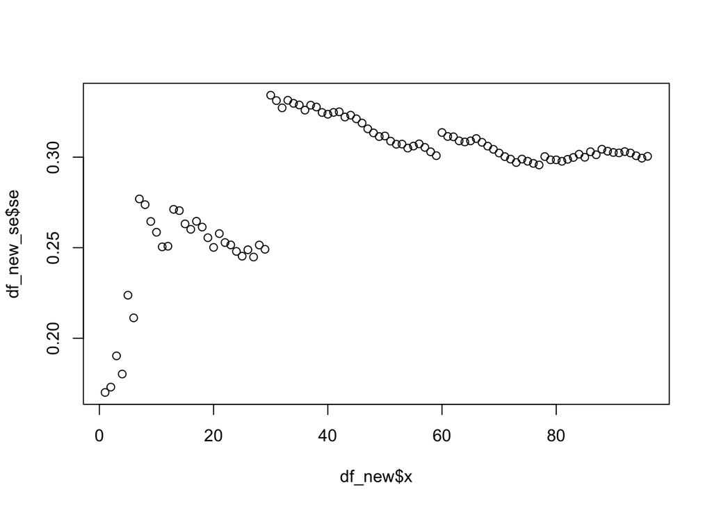

```r
par(plot(df_new$x, df_new$s),plot(df_new$x, df_new_se$se)) #use par and write out the two plots from above
```

Extra Credit. Making beautiful tables is hard. There are a number of good packages to help you do that - and they were recently featured in this excellent article - https://rfortherestofus.com/2019/11/how-to-make-beautiful-tables-in-r/. Make a beautiful table showing the average properties of bills of penguins by species, sex, and island. Use whatever package you like. A basic nice table is worth 4 points. +1 for every additional bit of information you can convey with the table other than a nicely formatted table. Please explain what you have done to get each point. +1 for naturally incorporating each additional piece of information about properties beyond means. How visually appealing can you make this?

```r
library(gt)
library(tidyverse)
penguins_table <-  penguins%>%
  group_by(species,sex, island)%>% #load in data group by species, sex, island
   summarize(avg_bill_length=mean(bill_length_mm, na.rm = TRUE), avg_bill_depth= mean(bill_depth_mm, na.rm = TRUE))%>% #summarize to get avg
  mutate("species_islands_sex" =  paste(species, island, sex, sep = '_'))%>% #mashe the column together to be species island and sex
  select(species_islands_sex, avg_bill_length, avg_bill_depth) #select for the new three columns
penguins_table%>% gt() #view data
```

| species_islands_sex | avg_bill_length | avg_bill_depth |
| --- | --- | --- |
| Adelie - female |  |  |
| Adelie_Biscoe_female | 37.35909 | 17.70455 |
| Adelie_Dream_female | 36.91111 | 17.61852 |
| Adelie_Torgersen_female | 37.55417 | 17.55000 |
| Adelie - male |  |  |
| Adelie_Biscoe_male | 40.59091 | 19.03636 |
| Adelie_Dream_male | 40.07143 | 18.83929 |
| Adelie_Torgersen_male | 40.58696 | 19.39130 |
| Adelie - NA |  |  |
| Adelie_Dream_NA | 37.50000 | 18.90000 |
| Adelie_Torgersen_NA | 37.92500 | 18.17500 |
| Chinstrap - female |  |  |
| Chinstrap_Dream_female | 46.57353 | 17.58824 |
| Chinstrap - male |  |  |
| Chinstrap_Dream_male | 51.09412 | 19.25294 |
| Gentoo - female |  |  |
| Gentoo_Biscoe_female | 45.56379 | 14.23793 |
| Gentoo - male |  |  |
| Gentoo_Biscoe_male | 49.47377 | 15.71803 |
| Gentoo - NA |  |  |
| Gentoo_Biscoe_NA | 45.62500 | 14.55000 |

```r
tab <- penguins_table%>%
  gt(rowname_col = "species_islands_sex")%>% #make species_islands_sex the col name
  tab_header("Average bill properties of penguins")%>% #name the chart
  tab_options(column_labels.background.color = "grey") # make the row header grey
tab #view
```

Average bill properties of penguins

|  | avg_bill_length | avg_bill_depth |
| --- | --- | --- |
| Adelie - female |  |  |
| Adelie_Biscoe_female | 37.35909 | 17.70455 |
| Adelie_Dream_female | 36.91111 | 17.61852 |
| Adelie_Torgersen_female | 37.55417 | 17.55000 |
| Adelie - male |  |  |
| Adelie_Biscoe_male | 40.59091 | 19.03636 |
| Adelie_Dream_male | 40.07143 | 18.83929 |
| Adelie_Torgersen_male | 40.58696 | 19.39130 |
| Adelie - NA |  |  |
| Adelie_Dream_NA | 37.50000 | 18.90000 |
| Adelie_Torgersen_NA | 37.92500 | 18.17500 |
| Chinstrap - female |  |  |
| Chinstrap_Dream_female | 46.57353 | 17.58824 |
| Chinstrap - male |  |  |
| Chinstrap_Dream_male | 51.09412 | 19.25294 |
| Gentoo - female |  |  |
| Gentoo_Biscoe_female | 45.56379 | 14.23793 |
| Gentoo - male |  |  |
| Gentoo_Biscoe_male | 49.47377 | 15.71803 |
| Gentoo - NA |  |  |
| Gentoo_Biscoe_NA | 45.62500 | 14.55000 |